# Comparing the mean TE copy numbers in males and females

# Unbiased Population Variation of Human Transposable Elements - Script 5

This is the fifth out of eight scripts describing the creation and analysis of the dataset of human TE abundance. This script works with the version of the HGDP dataset created in Script 2. In this script, we will perform the first actual analyses of TE content in the HGDP dataset. Specifically, we aim to compare the TE abundance between males and females from the samples.

A few things in advance: Not all populations have samples of both sexes. In total, much fewer samples are females than males, and for many populations only male samples are available. Keep this in mind for future analyses, as you will see that at the end of this section, we will decide to perform all future analyses for males and females separately, as they show substantial differencxes in TE abundance. The most likely reason for the observed abundance differences are differences in TE content between the X-chromosome and the Y-chromosome.

As with any analyses presented in this script series, they are by no means a fully comprehensive set. I am sure there are various additional aspects that could be studied.

We use the dataset produced at the end of Script 2.

```r
library(tidyverse)
#setwd(~/human-data)
HGDPcutoff<-read_delim("summary-HGDP/USEME_HGDP_complete_reflib6.2_mq10_batchinfo_cutoff0.01.txt",comment="#")
names(HGDPcutoff)<-c("ID","Pop","sex","Country","type","familyname","length","reads","copynumber","batch")
```

As we want to compare all males vs all females, we subset the data regarding the gender. Additionally, we are only interested in the abunance differences in TEs. Thus, we also subset only for TE sequences.

```r
ftecutoff<-subset(HGDPcutoff, sex=="female" & type=="te")
mtecutoff<-subset(HGDPcutoff, sex=="male" & type=="te")
```

### Calculating mean abundance for males and females

With this code, we can calculate the mean abundance for each TE sequence over all female or male samples regardless of their origin. Additionally, we create a dataframe that can be easily used for plotting with ggplot2.

```r
#Function to calculate means in the column 'copynumber'; written by Misaki Hu
meancopynumber<-function(df){ #input=data, newname= name of the newly produced list
  newname<-c()
  for(x in unique(df$familyname)){
    newname<-c(newname, mean(as.numeric(df[df$familyname==x,]$copynumber)))}
  return(newname)
}
ftecutoffmean<- meancopynumber(ftecutoff)
mtecutoffmean<-meancopynumber(mtecutoff)
malefemale_means<- data.frame(#Create a dataframe that can be used for plotting with ggplot
  tenames=unique(ftecutoff$familyname),#Note: We could also use mtecutoff, both sets have all TE sequences that remained after the subsetting in script 2, i.e. 965 sequences
  malemean=mtecutoffmean,
  femalemean=ftecutoffmean)
```

### Comparing mean abundance between males and females

We want to create a plot that shows a pairwise comparison of the mean copy number estimates of males and females for each of the 965 TE sequences. Additionally, we include a linear regression line (in grey) as well as a dashed line representing the null expectation for the regression, i.e. that males and females have the same mean abundance values and the regression should thus have a slope of 1. The regression line having a slope slightly lower than one is thus an indication (though not a proof) that TEs in females (x-axis) might be on average slightly more abundant than TEs in males (y-axis).

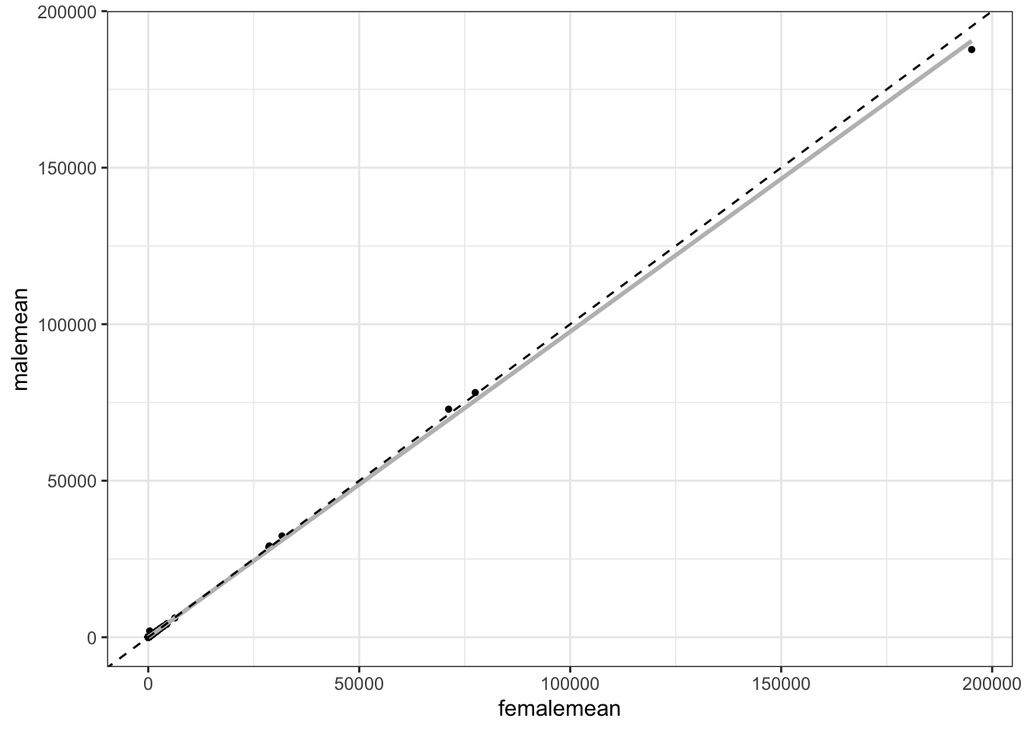

```r
ggplot(data=malefemale_means, mapping = aes(x=femalemean, y=malemean))+
  geom_point(size=1)+
  geom_smooth(method="lm",color="grey", se=F)+geom_abline(slope=1,linetype='dashed')+theme_bw()
```

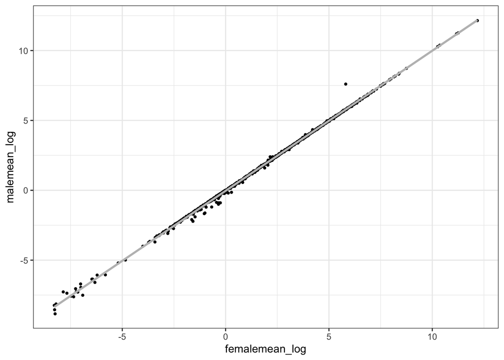

```r
malefemale_means_log<-data.frame(
  tenames=unique(ftecutoff$familyname),
  malemean_log=log(mtecutoffmean),
  femalemean_log=log(ftecutoffmean))
ggplot(data=malefemale_means_log, mapping = aes(x=femalemean_log, y=malemean_log))+
  geom_point(size=0.8)+
  geom_smooth(method="lm",color="grey", se=F)+theme_bw()
```

Either way, the main take away from this plot, for me at least, is that we do see quite some differences in the mean abundance comparison of males and females for at least a few TEs.

Let's look at those differences in a bit more detail, shall we?

### Relative and absolute mean differences between the sexes

#### Relative differences

First, we need to create a dataframe suitable for the planned analysis. For this, we calculate the relative difference of mean abundance between males and females in the column 'relmeandiff' of the new dataframe.

```r
meandiffframe<-data.frame(tenames=malefemale_means$tenames,relmeandiff=malefemale_means$malemean/malefemale_means$femalemean) # Create a suitable dataframe to create the plots
```

In the initial version, all pairwise differences where the mean of a TE for females is higher than the mean value for males have a value below 1. For example, a mean TE abundance of 3 copies for males and 6 copies for females would yield a value of 3/6=0.5. Contrarily, a mean TE abundance of 6 copies for males and 3 copies for females would yield a value of 6/3=2. Displaying such pairwise differences in a barplot can be deceptive. Presumably, one would want to display the deviations from the expected value, which is no difference, i.e. a value of 1. However, a value of 2 looks twice as large on a barplot than a value of 0.5. For this reason, I calculate the inverse for all values below one. In our example, the inverse of 0.5 is 1/0.5=2. This way. pairwise differences between males and females can be analyzed comprehensively while disregarding in which sex the TE is more abundant. However, if a TE is more abundant in males or females is vital information to analyze the data comprehensively. If the initial value is below 1 this implies that the value for mean abundance in females is higher than in males (see above). Though, I do not only calculate the inverse within the loop, but I also indicate that the respective bar should be colored in red. Red color thus represents a higher TE abundance in females than males. Contrarily, adding 'blue' to the vector indicates that the mean abundance for the respective sequence was higher in males than females. Adding this vector to the dataframe allows us to use this information and display the bars in the barplot to indicate in which sex they are more abundant.

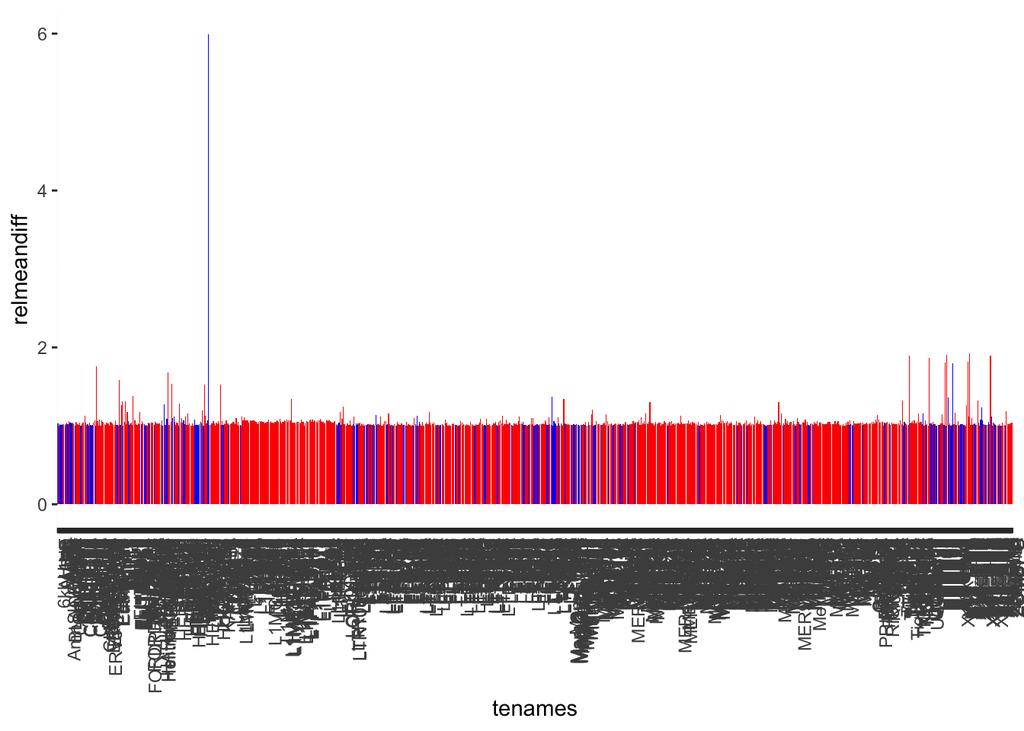

```r
colorvec<-c()
for (i in 1:length(meandiffframe$tenames)){
  if (meandiffframe$relmeandiff[i]<1){
    meandiffframe$relmeandiff[i]<-1/meandiffframe$relmeandiff[i]
    colorvec<-c(colorvec,'red')  }
  else{
    colorvec<-c(colorvec,'blue')  }}
meandiffframe$fillcol<-colorvec
ggplot(data=meandiffframe, aes(x=tenames, y=relmeandiff))+
  geom_bar(stat="identity", fill=meandiffframe$fillcol)+
  theme(axis.text.x = element_text(angle = 90, hjust = 1))
```

As you might see, producing a plot with all 965 TEs is quite difficult to interpret. Also, a random order of the TEs does not help the interpretability of the plot. Ordering the display order of the TEs by their difference in abundance helps to make the plot more interpretable.

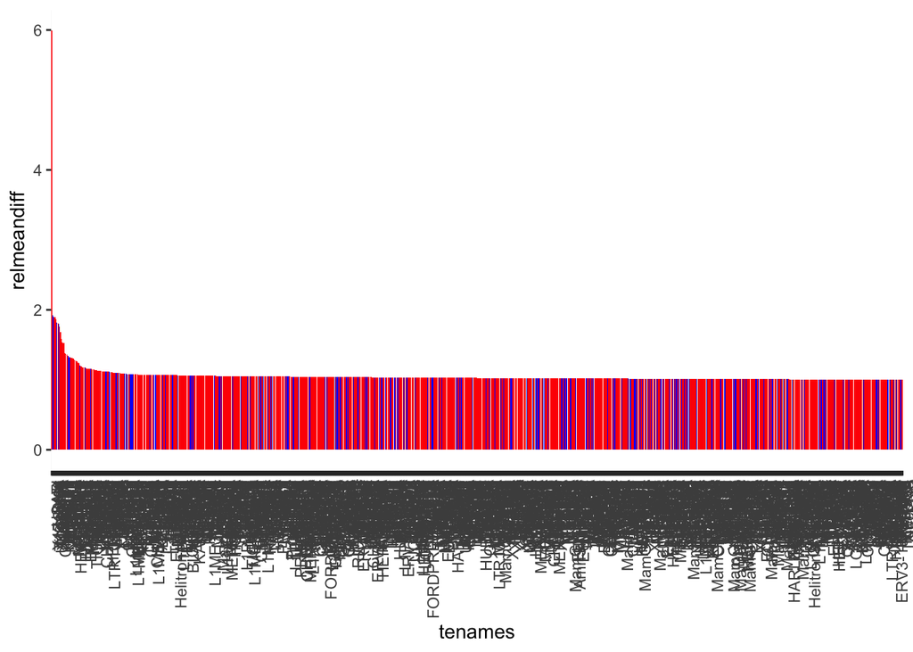

```r
ordermeandiffframe<-meandiffframe[order(meandiffframe$relmeandiff,decreasing=T),]
ordermeandiffframe$tenames<-factor(ordermeandiffframe$tenames,levels=ordermeandiffframe$tenames)
ggplot(data=ordermeandiffframe, aes(x=tenames, y=relmeandiff))+
  geom_bar(stat="identity", fill=meandiffframe$fillcol)+
  theme(axis.text.x = element_text(angle = 90, hjust = 1))
```

While this most certainly helps, wouldn't it be nice to focus on just a few TEs that show the highest abundance differences? Worry not, subsetting is your friend.

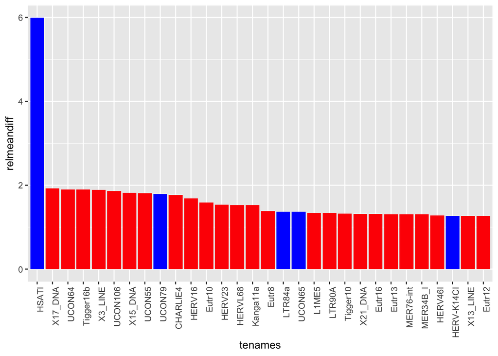

```r
subsampleordermeandiffframe<-ordermeandiffframe[1:30,]#This number is arbitrary, feel free to look at more/less TEs in the plot
subsampleordermeandiffframe$tenames<-factor(subsampleordermeandiffframe$tenames,levels=subsampleordermeandiffframe$tenames)
ggplot(data=subsampleordermeandiffframe, aes(x=tenames, y=relmeandiff))+
  geom_bar(stat="identity", fill=subsampleordermeandiffframe$fillcol)+
  theme(axis.text.x = element_text(angle = 90, hjust = 1))
```

The sequence with the highest abundance difference is actually a satellite, and we have also seen in Script 1 that this sequence is quite vulnerable to estimation differences caused by differences in the data. So how relevant this is is debatable, I think it might not be very relevant.  
What I did find interesting looking at this is that we see L1ME5, which seems to be the version of L1 that shows the most differences between the populations, i.e. I believe it to be the most recently active L1, or at least obne of them. When checking the literature, I found that it is apparently known that L1 is quite abundant on the X-chromosome. This seems like it confirms quite nicely with the observed results here, so I found that to be quite neat.

#### Absolute differences

When looking at the absolute mean differences instead of the relative ones, we again see the extreme abundance of Alu and some of its variants like Alr, Alr1 and Alr_. Again, red color indicates that the mean of TE copy number is higher in females, and blue suggests that it is higher in males.

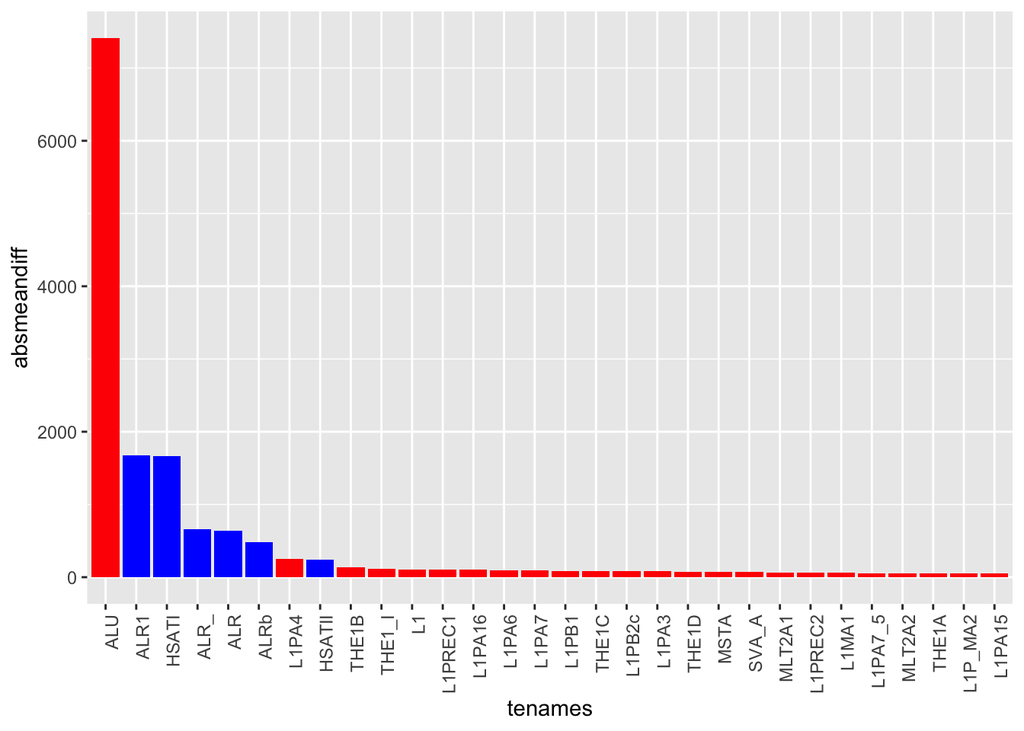

```r
meandifabsframe<-data.frame(tenames=malefemale_means$tenames,absmeandiff=abs(malefemale_means$malemean-malefemale_means$femalemean))
colorvecabs<-c()
for (i in 1:length(malefemale_means$malemean-malefemale_means$femalemean)){
  if (malefemale_means$malemean[i]-malefemale_means$femalemean[i]<0){
    colorvecabs<-c(colorvecabs,'red')
  }
  else{
    colorvecabs<-c(colorvecabs,'blue')  }}
meandifabsframe$fillcol<-colorvecabs
ordermeandifabsframe<-meandifabsframe[order(meandifabsframe$absmeandiff,decreasing=T),]
subsampleordermeandifabsframe<-ordermeandifabsframe[1:30,]
subsampleordermeandifabsframe$tenames<-factor(subsampleordermeandifabsframe$tenames,levels=subsampleordermeandifabsframe$tenames)

ggplot(data=subsampleordermeandifabsframe, aes(x=tenames, y=absmeandiff))+
  geom_bar(stat="identity", fill=subsampleordermeandifabsframe$fillcol)+
  theme(axis.text.x = element_text(angle = 90, hjust = 1))
```

I am not sure if there is much additional information to obtain from the absolute comparison. Thus, I did not include the plot version for the full dataset. However, it shouldnt be hard to produce it using the ordered dataset before subsetting (compare to the code for the 'relative' plot).

But more generally, what do these results mean? I think what we see here is mainly a difference in abundance between TEs found on the X-chromosome vs TEs found on the Y-chromosome. As a word of caution, in the female dataset various populations are missing. Potentially, this could influence some of the abundance differences seen here. This should be reanalyzed when the results for the comparisons of the different populations are obtained (not yet performed as the time of this writing).

I wanted to make a statistical test indicating if males and females actually have significantly different relative abundances. I calculated a standard nonparametric test, the Wilcoxon rank-sum test, comparing all results for males with all results for females and testing if their ranks are randomly distributed.

```r
wilcox.test(ordermeandiffframe$relmeandiff[ordermeandiffframe$fillcol=='red'],ordermeandiffframe$relmeandiff[ordermeandiffframe$fillcol=='blue'])
```

[output not shown]

The test is significant, indicating that there are inherent abundance differences between males and females, which was also suggested from looking at the plots above.  
For this reason, any upcoming analysis will be performed independently for males and females to avoid systematic differences that could influence the comparisons on Continent- or population-level.